# Data Open Lecture: An Introduction of R

# ggplot2: An Advanced Plot for Data Frame

ggplot(data, mapping = aes(x = x, y = y, …)) + geom…()

- ggplot(data, mapping): prepare data for plot
- aes(): select variables to map (x,y) and groupby (fill/color/…)
- geom…(): how we show the data we select in ggplot

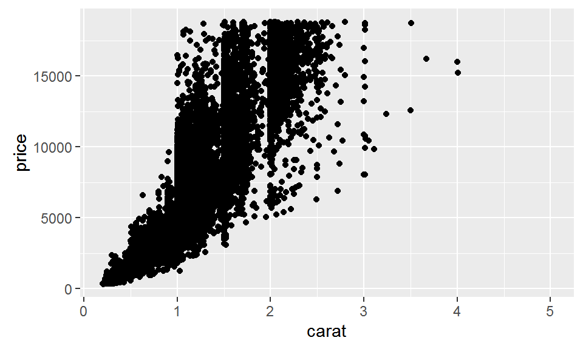

```r
library("ggplot2")
ggplot(data, aes(x = carat, y = price)) + geom_point()
```

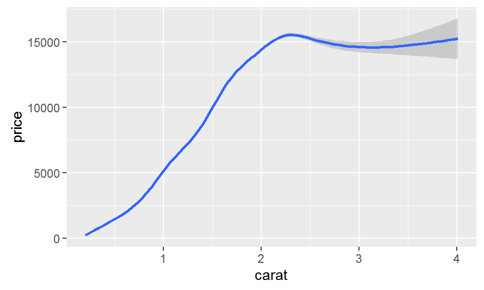

```r
ggplot(data, aes(x = carat, y = price)) + geom_smooth()
```

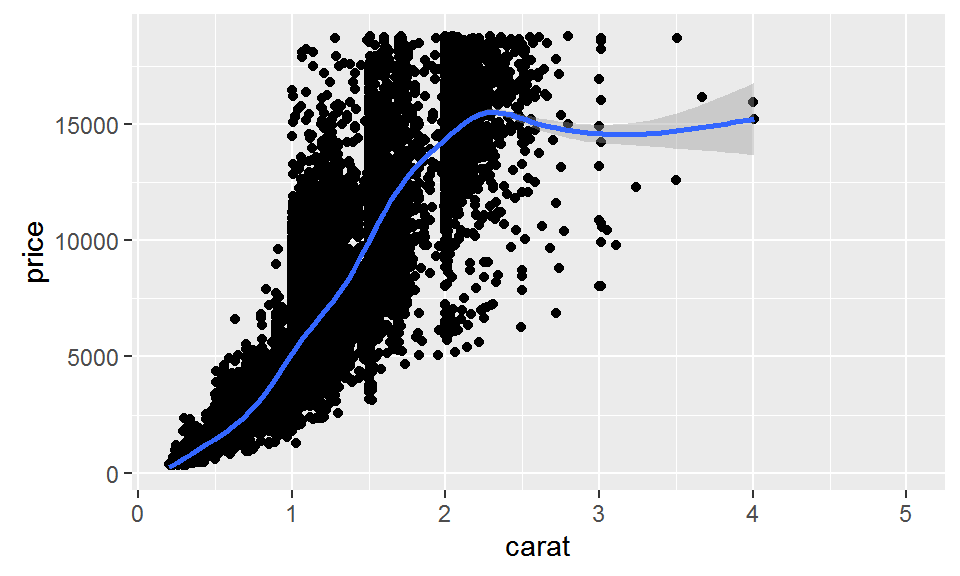

```r
ggplot(data, aes(x = carat, y = price)) + geom_point() + geom_smooth()
```

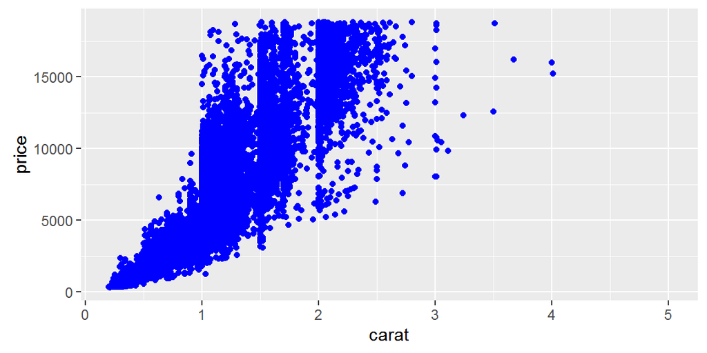

```r
ggplot(data, aes(x = carat, y = price)) + geom_point(color = "blue")
```

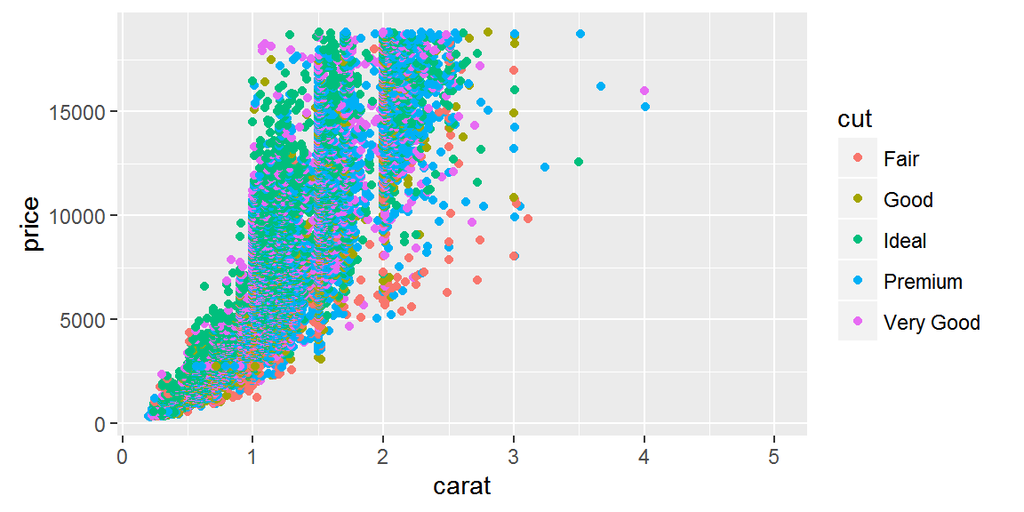

```r
ggplot(data, aes(x = carat, y = price, color = cut)) + geom_point()
```

# Frequency and Distribution

- Plot: bar$\rightarrow$categorical and histogram/density$\rightarrow$numeric

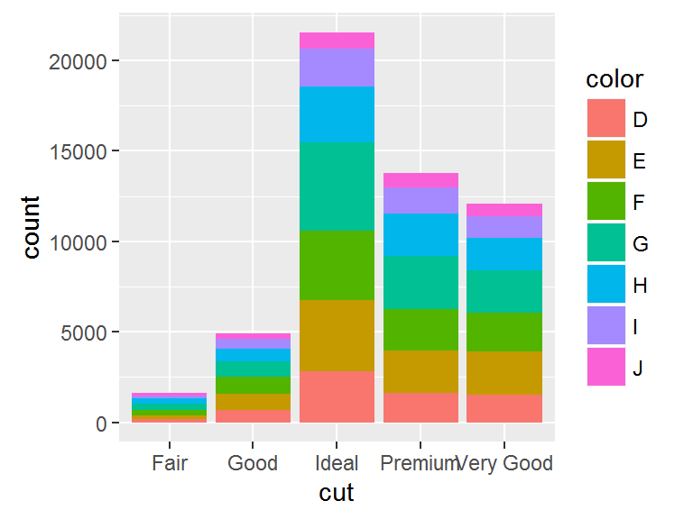

```r
ggplot(data, aes(x = cut)) + geom_bar(aes(fill = color))
```

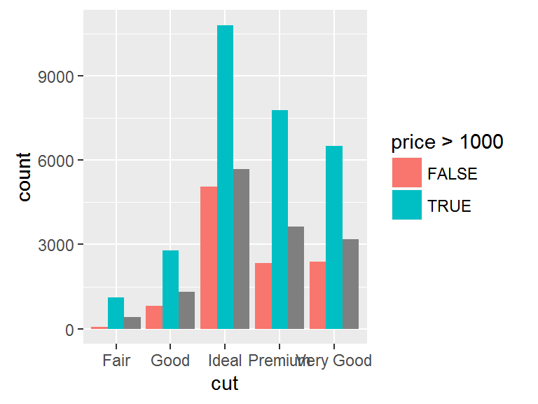

```r
ggplot(data, aes(x = cut)) + geom_bar(aes(fill = price > 1000), position=position_dodge())
```

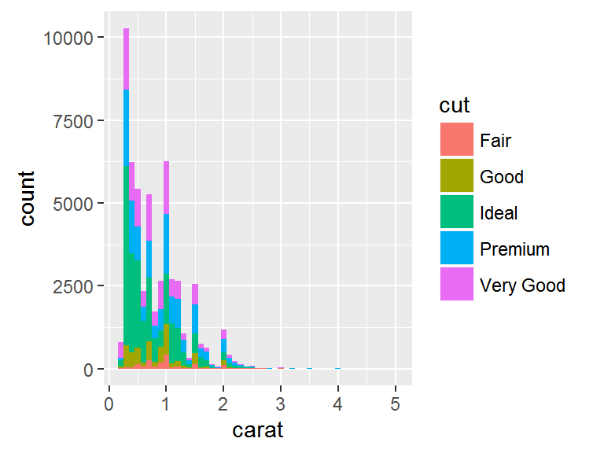

```r
ggplot(data, aes(x = carat)) + geom_histogram(aes(fill = cut), binwidth = 0.1)
```

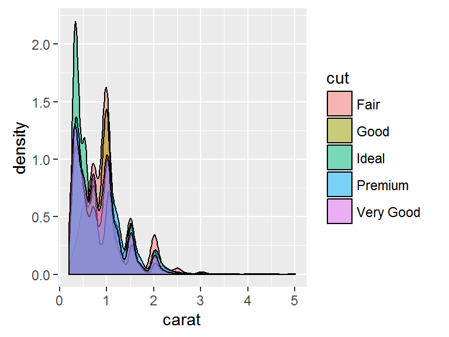

```r
ggplot(data, aes(x = carat)) + geom_density(aes(fill = cut), alpha = 0.5)
```

- Counting in data.table, use .N (the length) and by = …

```r
data[, list(count = .N), by = cut]
```

```
##          cut count
## 1:     Ideal 21551
## 2:   Premium 13791
## 3:      Good  4906
## 4: Very Good 12082
## 5:      Fair  1610
```

```r
data[, list(count = .N), by = list(carat = cut(carat, breaks = 3))]
```

```
##          carat count
## 1: (0.195,1.8] 51666
## 2:  (1.8,3.41]  2264
## 3: (3.41,5.01]    10
```

# Groupby in data.table

- data.table has the form: data[i, j, by = …]

```r
data[i = price > 1000, j = list(count = .N, mean = mean(carat), sd = sd(carat))]
```

```
##    count      mean        sd
## 1: 29024 0.9679445 0.4457943
```

```r
data[i = price > 1000, j = list(count = .N, mean = mean(carat), sd = sd(carat)), by = list(cut)]
```

```
##          cut count      mean        sd
## 1:      Fair  1114 1.0813914 0.4774036
## 2:     Ideal 10814 0.8757287 0.4268839
## 3: Very Good  6507 0.9784555 0.4122846
## 4:      Good  2795 0.9967263 0.4145200
## 5:   Premium  7794 1.0605799 0.4781261
```

- Groupby functions in data.table, ggplot2 and SQL (a database language)

| R | ggplot2 | SQL |
| --- | --- | --- |
| i |  | WHERE |
| j | aes(x, y) | SELECT |
| by | aes(color/fill/…) | GROUP BY |

# Column Apply in data.table

- Apply on each column in data.table with lapply(.SD, function)

```r
data[,lapply(.SD, class)]
```

```
##          n   carat       cut     color   clarity   depth   table   price
## 1: integer numeric character character character numeric numeric integer
##          x       y       z
## 1: numeric numeric numeric
```

- We can also define functions for use

```r
summary_num = function(x){
    if(class(x) == "character") return(NA)
    else return(c(mean = mean(x, na.rm = T), sd = sd(x, na.rm = T), quantile(x, na.rm = T)))
}
summary_num(data[,price])
```

```
##      mean        sd        0%       25%       50%       75%      100%
##  3928.360  3992.675   326.000   949.000  2397.000  5302.250 18818.000
```

```r
data[,lapply(.SD, summary_num)]
```

```
##           n     carat cut color clarity     depth     table     price
## 1: 26970.50 0.7979397  NA    NA      NA 61.749405 57.457184  3928.360
## 2: 15571.28 0.4740112  NA    NA      NA  1.432621  2.234491  3992.675
## 3:     1.00 0.2000000  NA    NA      NA 43.000000 43.000000   326.000
## 4: 13485.75 0.4000000  NA    NA      NA 61.000000 56.000000   949.000
## 5: 26970.50 0.7000000  NA    NA      NA 61.800000 57.000000  2397.000
## 6: 40455.25 1.0400000  NA    NA      NA 62.500000 59.000000  5302.250
## 7: 53940.00 5.0100000  NA    NA      NA 79.000000 95.000000 18818.000
##            x         y          z
## 1:  5.731157  5.734526  3.5387338
## 2:  1.121761  1.142135  0.7056988
## 3:  0.000000  0.000000  0.0000000
## 4:  4.710000  4.720000  2.9100000
## 5:  5.700000  5.710000  3.5300000
## 6:  6.540000  6.540000  4.0400000
## 7: 10.740000 58.900000 31.8000000
```

# 6.3 R Linear Model

# Linear Model and Residuals

- Build a linear model in R with lm(formula = …, data)

```r
options(na.action = 'na.exclude')
model = lm(price ~ carat, data = data)
summary(model)
```

- Use plot for residual analysis

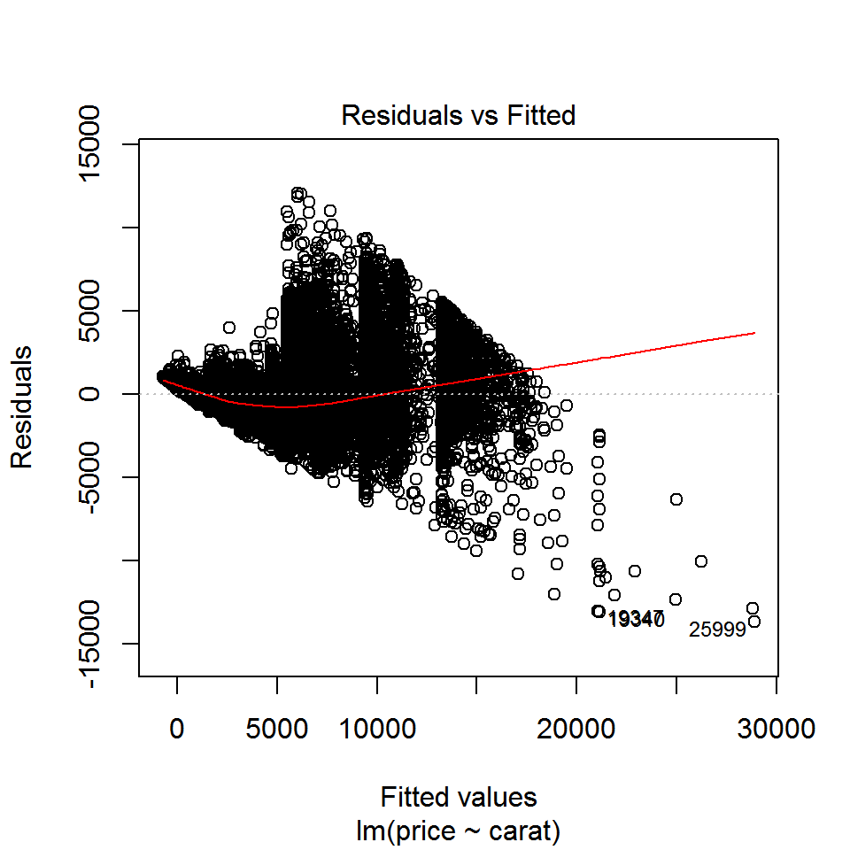

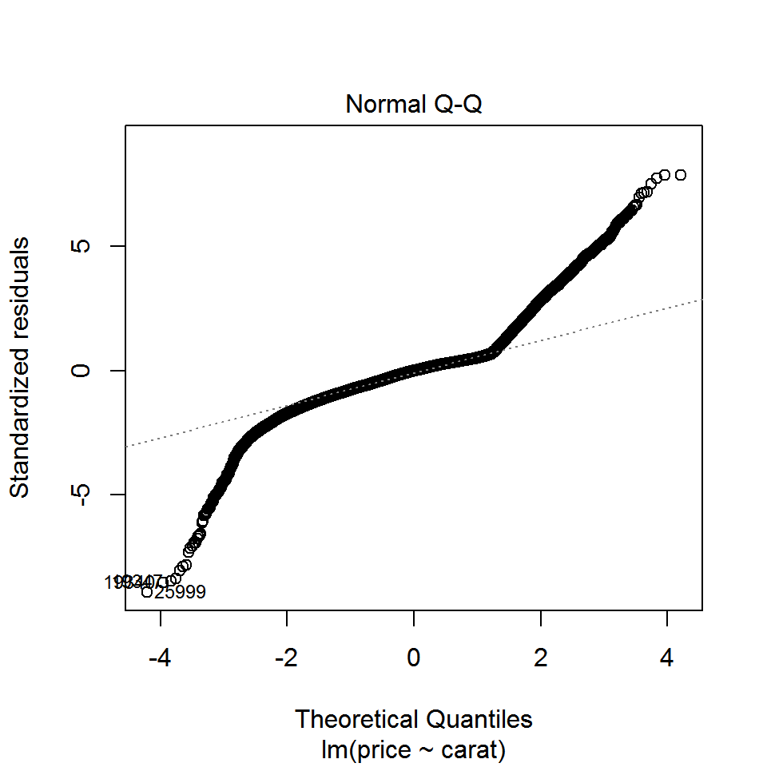

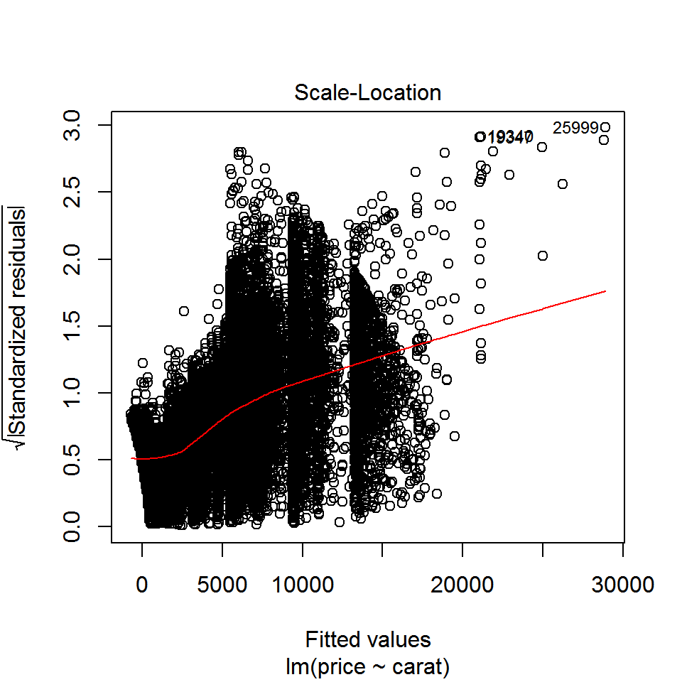

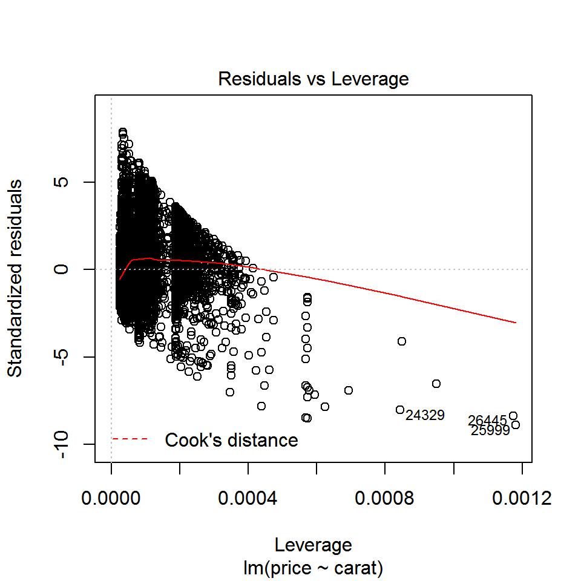

```r
plot(model)
```

# Variable Transformation

- We can use transformation functions on x and y

```r
model_log = lm(price ~ log(carat), data = data)
summary(model_log)
model_cut = lm(price ~ cut(carat, 5), data = data)
summary(model_cut)
model_poly1 = lm(price ~ poly(carat, 3), data = data)
summary(model_poly1)
model_poly2 = lm(price ~ poly(carat, 3, raw = TRUE), data = data)
summary(model_poly2)
```

- Use ggplot to plot univariate linear models

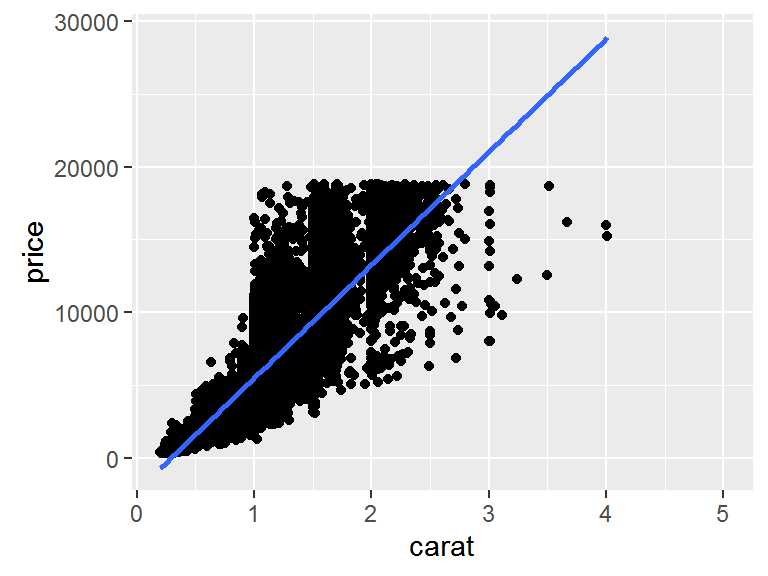

```r
ggplot(data, aes(x=carat,y=price)) + geom_point() + geom_smooth(method="lm")
```

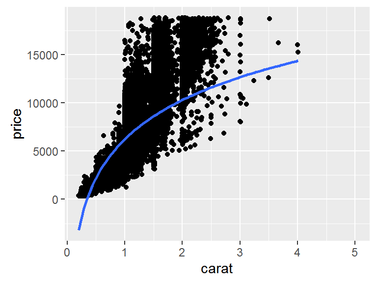

```r
ggplot(data, aes(x=carat,y=price)) + geom_point() + geom_smooth(method="lm", formula=y~log(x))
```

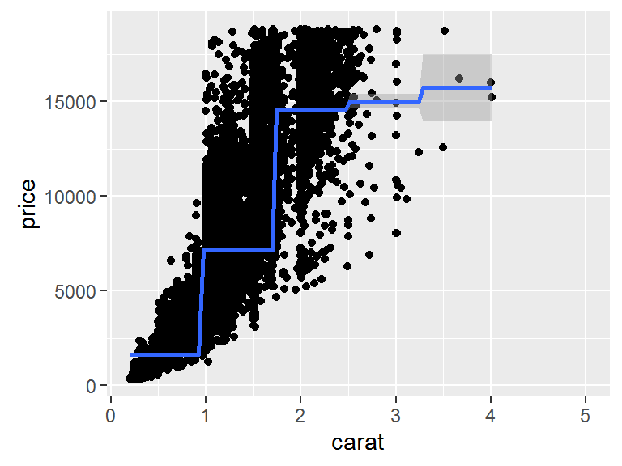

```r
ggplot(data, aes(x=carat,y=price)) + geom_point() + geom_smooth(method="lm", formula=y~cut(x,5))
```

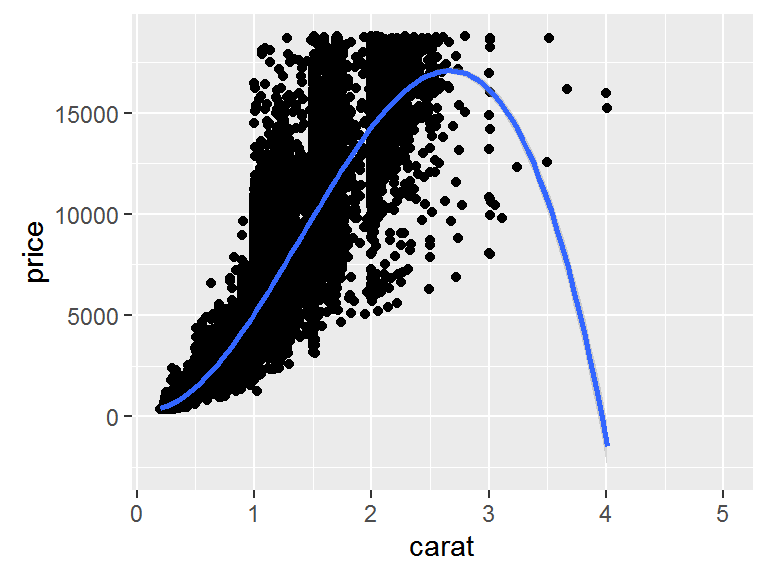

```r
ggplot(data, aes(x=carat,y=price)) + geom_point() + geom_smooth(method="lm", formula=y~poly(x,3))
```

# Multivariate Linear Models and ANOVA

- Use “+”: adding variables, “:”: interaction, and “*“: for both

```r
model1 = lm(price ~ carat + cut + carat:cut, data = data)
summary(model1)
model2 = lm(price ~ carat*cut, data = data)
summary(model2)
```

- Use ANOVA to test the effect of multi variables in the linear model

```r
anova(model1)
```

```
## Analysis of Variance Table
##
## Response: price
##              Df     Sum Sq    Mean Sq   F value    Pr(>F)
## carat         1 5.3925e+11 5.3925e+11 243069.75 < 2.2e-16 ***
## cut           4 4.3910e+09 1.0977e+09    494.82 < 2.2e-16 ***
## carat:cut     4 1.2771e+09 3.1927e+08    143.91 < 2.2e-16 ***
## Residuals 39698 8.8070e+10 2.2185e+06
## ---
## Signif. codes:  0 '***' 0.001 '**' 0.01 '*' 0.05 '.' 0.1 ' ' 1
```

# High-Dimensional Variables and Selection

- Put all variables except n into the model, “.”: all other variables, “-”: remove a variable

```r
model_all = lm(price ~ . - n, data = data)
summary(model_all)
```

- Stepwise selection with both forward and backward method

```r
model_step = step(model_all, direction = "both", trace = 0)
anova(model_step)
```

```
## Analysis of Variance Table
##
## Response: price
##              Df     Sum Sq    Mean Sq    F value    Pr(>F)
## carat         1 5.3925e+11 5.3925e+11 4.3204e+05 < 2.2e-16 ***
## cut           4 4.3910e+09 1.0977e+09 8.7951e+02 < 2.2e-16 ***
## color         6 9.2122e+09 1.5354e+09 1.2301e+03 < 2.2e-16 ***
## clarity       7 2.7850e+10 3.9786e+09 3.1877e+03 < 2.2e-16 ***
## depth         1 1.6634e+06 1.6634e+06 1.3327e+00    0.2483
## table         1 6.6218e+07 6.6218e+07 5.3054e+01 3.306e-13 ***
## x             1 2.6829e+09 2.6829e+09 2.1495e+03 < 2.2e-16 ***
## Residuals 39686 4.9534e+10 1.2481e+06
## ---
## Signif. codes:  0 '***' 0.001 '**' 0.01 '*' 0.05 '.' 0.1 ' ' 1
```